# Assignment - Dimension Reduction

# Nonnegative matrix factorization

The last technique for dimension reduction in this problem is nonnegative matrix factorization.

#### Running NMF

```r
# Scale the dataset
library(dplyr)
library(scales)
#install.packages("BiocManager")
#BiocManager::install("Biobase")

scaled_D <- D%>%mutate_if(is.double, rescale, to = c(0,1))
scaled_D
```

| price | mileage | year_1973 | year_1984 | year_1993 | year_1994 | year_1995 | year_1996 | year_1997 | year_1998 | year_1999 | year_2000 | year_2001 | year_2002 | year_2003 | year_2004 | year_2005 | year_2006 | year_2007 | year_2008 | year_2009 | year_2010 | year_2011 | year_2012 | year_2013 | year_2014 | year_2015 | year_2016 | year_2017 | year_2018 | … |
| --- | --- | --- | --- | --- | --- | --- | --- | --- | --- | --- | --- | --- | --- | --- | --- | --- | --- | --- | --- | --- | --- | --- | --- | --- | --- | --- | --- | --- | --- | --- |
| 0.0742049470 | 2.692871e-01 | 0 | 0 | 0 | 0 | 0 | 0 | 0 | 0 | 0 | 0 | 0 | 0 | 0 | 0 | 0 | 0 | 0 | 1 | 0 | 0 | 0 | 0 | 0 | 0 | 0 | 0 | 0 | 0 | … |
| 0.0341460542 | 1.871945e-01 | 0 | 0 | 0 | 0 | 0 | 0 | 0 | 0 | 0 | 0 | 0 | 0 | 0 | 0 | 0 | 0 | 0 | 0 | 0 | 0 | 1 | 0 | 0 | 0 | 0 | 0 | 0 | 0 | … |
| 0.0630153121 | 3.889243e-02 | 0 | 0 | 0 | 0 | 0 | 0 | 0 | 0 | 0 | 0 | 0 | 0 | 0 | 0 | 0 | 0 | 0 | 0 | 0 | 0 | 0 | 0 | 0 | 0 | 0 | 0 | 0 | 1 | … |
| 0.2944640754 | 6.301575e-02 | 0 | 0 | 0 | 0 | 0 | 0 | 0 | 0 | 0 | 0 | 0 | 0 | 0 | 0 | 0 | 0 | 0 | 0 | 0 | 0 | 0 | 0 | 0 | 1 | 0 | 0 | 0 | 0 | … |
| 0.3262661955 | 6.536757e-03 | 0 | 0 | 0 | 0 | 0 | 0 | 0 | 0 | 0 | 0 | 0 | 0 | 0 | 0 | 0 | 0 | 0 | 0 | 0 | 0 | 0 | 0 | 0 | 0 | 0 | 0 | 0 | 1 | … |
| 0.0671378092 | 4.475822e-02 | 0 | 0 | 0 | 0 | 0 | 0 | 0 | 0 | 0 | 0 | 0 | 0 | 0 | 0 | 0 | 0 | 0 | 0 | 0 | 0 | 0 | 0 | 0 | 0 | 0 | 0 | 0 | 1 | … |
| 0.0859835100 | 1.464237e-01 | 0 | 0 | 0 | 0 | 0 | 0 | 0 | 0 | 0 | 0 | 0 | 0 | 0 | 0 | 0 | 0 | 0 | 0 | 0 | 1 | 0 | 0 | 0 | 0 | 0 | 0 | 0 | 0 | … |
| 0.1572438163 | 2.311049e-02 | 0 | 0 | 0 | 0 | 0 | 0 | 0 | 0 | 0 | 0 | 0 | 0 | 0 | 0 | 0 | 0 | 0 | 0 | 0 | 0 | 0 | 0 | 0 | 0 | 0 | 0 | 1 | 0 | … |
| 0.1719670200 | 9.205883e-03 | 0 | 0 | 0 | 0 | 0 | 0 | 0 | 0 | 0 | 0 | 0 | 0 | 0 | 0 | 0 | 0 | 0 | 0 | 0 | 0 | 0 | 0 | 0 | 0 | 0 | 0 | 0 | 1 | … |
| 0.0618374558 | 6.230058e-02 | 0 | 0 | 0 | 0 | 0 | 0 | 0 | 0 | 0 | 0 | 0 | 0 | 0 | 0 | 0 | 0 | 0 | 0 | 0 | 0 | 0 | 0 | 0 | 0 | 0 | 0 | 1 | 0 | … |

[output cut: 990 more lines]

```r
#Check if scaled_D has any negative numbers
range(scaled_D)
```

```
[1] 0 1
```

```r
nmf_D <- NMF::nmf(scaled_D, 2)
nmf_D
```

```
<Object of class: NMFfit>
 # Model:
  <Object of class:NMFstd>
  features: 2499
  basis/rank: 2
  samples: 32
 # Details:
  algorithm:  brunet
  seed:  random
  RNG: 10403L, 350L, ..., -774796928L [d1ec5fdecf1361739a0d12bb414b51a0]
  distance metric:  'KL'
  residuals:  3549.909
  Iterations: 420
  Timing:
     user  system elapsed
     0.28    0.00    0.28
```

#### Using the NMF basis function to retrieve a new dataset with reduced columns

```r
basis_D <- NMF::basis(
  object = nmf_D
)

coef_D <- NMF::coef(
  object = nmf_D
)

dim(basis_D)
```

```
[1] 2499    2
```

```r
dim(coef_D)
```

```
[1]  2 32
```

```r
colnames(basis_D) <- c(
  "topic_1","topic_2"
)
rownames(coef_D) <- c(
  "topic_1","topic_2"
)
round(head(basis_D),3)
```

```
     topic_1 topic_2
[1,]   1.223   0.000
[2,]   1.111   0.000
[3,]   0.000   0.752
[4,]   1.235   0.000
[5,]   0.000   0.910
[6,]   0.000   0.759
```

```r
round(coef_D,3)
```

```
        price mileage year_1973 year_1984 year_1993 year_1994 year_1995 year_1996 year_1997 year_1998 year_1999 year_2000
topic_1 0.153   0.068     0.001     0.000     0.000     0.000     0.001     0.002     0.002     0.003     0.000     0.000
topic_2 0.295   0.033     0.000     0.001     0.001     0.002     0.000     0.000     0.000     0.000     0.001     0.003
        year_2001 year_2002 year_2003 year_2004 year_2005 year_2006 year_2007 year_2008 year_2009 year_2010 year_2011
topic_1     0.004     0.002     0.007     0.000     0.005     0.006     0.000     0.014     0.009     0.000     0.018
topic_2     0.000     0.000     0.000     0.005     0.000     0.000     0.005     0.000     0.000     0.011     0.000
        year_2012 year_2013 year_2014 year_2015 year_2016 year_2017 year_2018 year_2019 year_2020
topic_1     0.056     0.067     0.081     0.152     0.158     0.293     0.000     0.000      0.00
topic_2     0.000     0.000     0.000     0.000     0.000     0.000     0.328     0.741      0.04
```

#### Plotting the two basis vectors

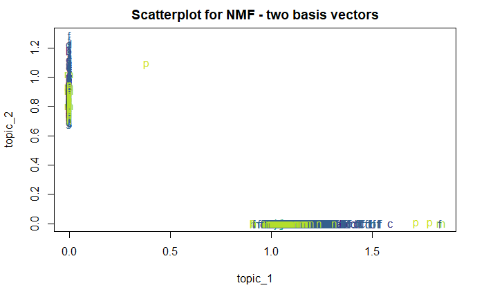

```r
plot(basis_D,
     col = brand_color,
     pch = as.character(brand),
     main = "Scatterplot for NMF - two basis vectors")
```

Looking at the scatter plot above, we can see some separation between the data points. however, the data still seems to be clumped together. The numeric data was scaled in the steps above to be on a scale of 0-1, which is why the data points are flat on both axes. Even though the data points are clumped together, the separation between p and the other data points is seen similar to the PCA plot above. However, PCA seemed to do a better job of grouping the p points together and separate from the rest of the data points. Whereas, t-SNE had data points all scattered throughout the plot before and after adjusting the parameters for the Rtsne function. Furthermore, although PCA had the data points clumped together, it seemed to have chunks of data points separate from each other. This can be interpreted from the analysis of predicting a car brand using price, mileage, and year. The analysis shows that different brands of cars can be in different categories, for example; High-mileage, High-price, and Latest Year.

During the analysis, a key issue was highlighted, which could also be a problem in our analysis. The number of brands of cars are disproportionate, which makes this problem more complicated. A better analysis could be performed to predict brand of a car using price, mileage, and the year if the proportion of car brands were somewhat equal in the data.